# Lake Okeechobee and Caloosahatchee River Estuary Conditions

Updated 2021-09-21 08:20:56

## Lake Okeechobee

### Stage Elevation

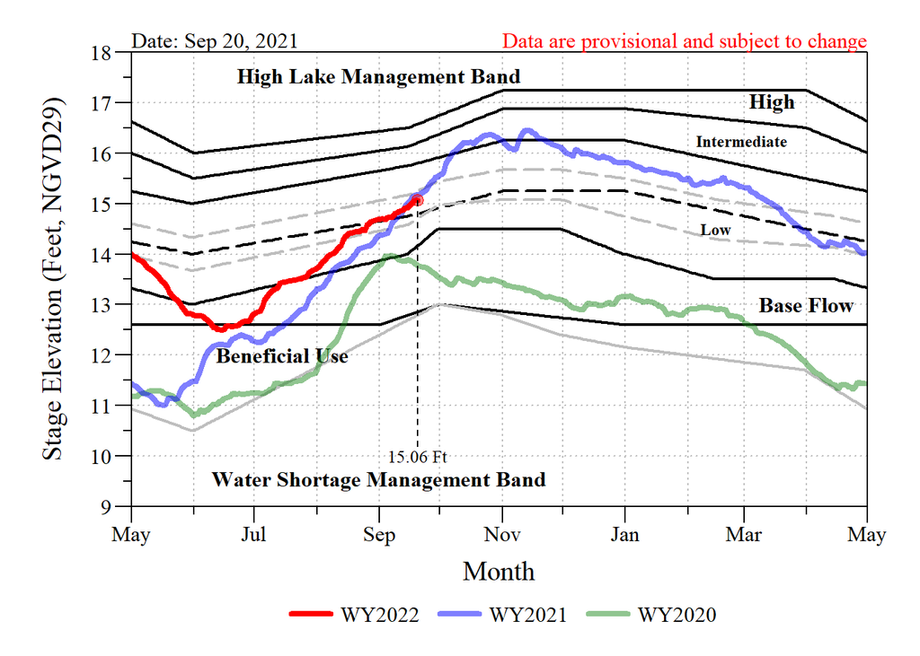

Lake Okeechobee daily average stage elevation for water year 2022 (WY2022) relative to the last two water years (red line) relative to the Lake Okeechobee Regulation Schedule (LORS) .

Data are provisional and subject to change.

| Stage and recession rates this time for the current and last three water years Date (Month-Day) | Stage and recession rates this time for the current and last three water years Water Year | Stage and recession rates this time for the current and last three water years Stage (ft, NGVD29) | Stage and recession rates this time for the current and last three water years 7-Day Recession Rate (ft 7-d⁻¹) | Stage and recession rates this time for the current and last three water years 30-Day Recession Rate (ft 30-d⁻¹) B |
| --- | --- | --- | --- | --- |
| 09-20 | 2019 | 14.73 | 0.02 | 0.14 |
| 09-20 | 2020 | 13.78 | -0.08 | 0.57 |
| 09-20 | 2021 | 15.17 | 0.29 | 1.12 |
| 09-20 | 2022 | 15.06 A | 0.19 | 0.61 |

A Value provided by SFWMD DBKEY:N3466  
B -0.5 ft 30-d⁻¹ maximum 30-day Recession Rate for HAB Deviation

- As of 09/20/2021 the mean stage elevation in Lake Okeechobee is within the Operational Low Sub- Management Band at a stage elevation of 15.06 feet (NGVD29).

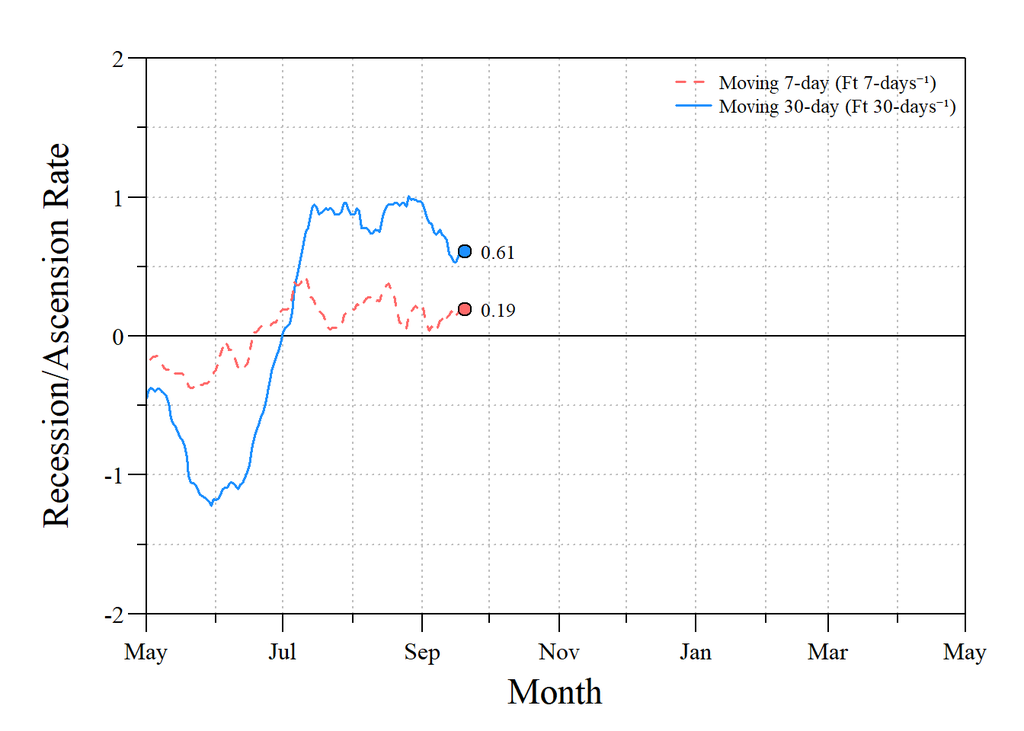

Lake Okeechobee 7-day and 30-day water level recession/ascension rates during WY2022. Negative values indicate falling water levels (recession) and positive values indicate raising water level (ascension) during this 7-day period .

Data are provisional and subject to change.

### Regional Rainfall

| Weekly (09/14 - 09/20) rainfall totals along the Caloosahatchee River Mointoring Location 1 | Weekly (09/14 - 09/20) rainfall totals along the Caloosahatchee River Weekly Rainfall Total (inches) 2 |
| --- | --- |
| S79 (WP Franklin) | 2.4 |
| S78 (Ortona) | 3.2 |
| S77 (Moore Haven) | 1.4 |

1 Data Source: SFWMD DBHYDRO (DBKEYS 16414,15495,16415) and USACE reports  
2 Based on data from 09/14/2021 - 09/20/2021

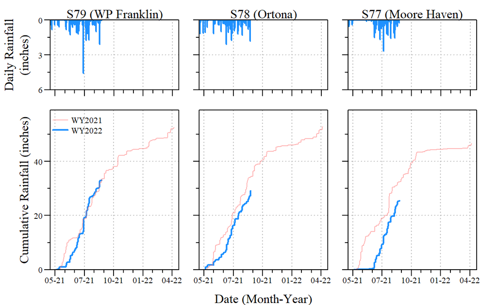

### Relative Algae Condition

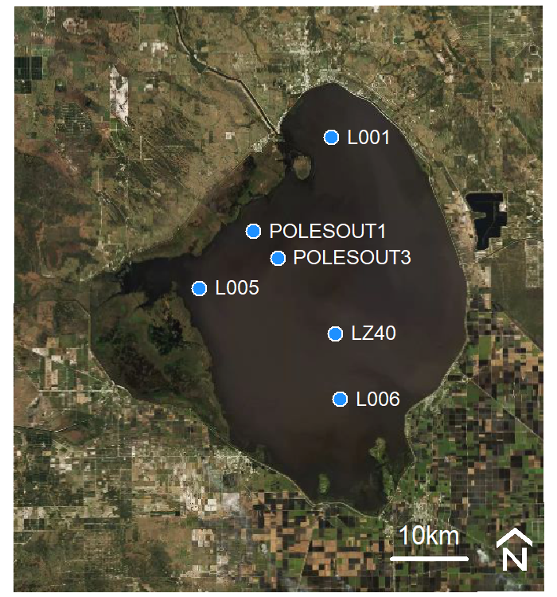

Sonde monitoring locations within Lake Okeechobee conducted by SFWMD.

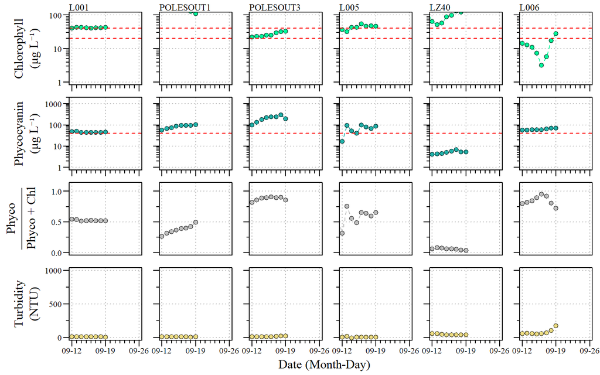

Daily Chlorophyll, Phycocyanin,relative ratio of Phycocyanin (Phyco) relative to Phyco and Chlorophyll (Chl) and Turbidity within Lake Okeechobee monitored by SFWMD. Chlorophyll and Phycocyanin are plotted on log-scale. Thresholds of concern/risk identified for Chlorophyll (20 and 40 μg/L) and Phycocyanin (40 μg/L; Cotterill et al 2019 & Macário et al 2015).

Data are provisional and subject to change.

- Cotterill et al (2019) Phycocyanin sensors as an early warning system for cyanobacteria blooms concentrations: a case study in the Rotorua lakes. New Zealand Journal of Marine and Freshwater Research 53:555–570.
- Macário et al (2015) New insights towards the establishment of phycocyanin concentration thresholds considering species-specific variability of bloom-forming cyanobacteria. Hydrobiologia 757:155–165.

| Weekly mean water quality sonde Chlorophyll and Phycocyanin concentration at monitoring locations across Lake Okeechobee Site | Weekly mean water quality sonde Chlorophyll and Phycocyanin concentration at monitoring locations across Lake Okeechobee 7-day Mean Chlorophyll Conc. (μg L⁻¹) 1 | Weekly mean water quality sonde Chlorophyll and Phycocyanin concentration at monitoring locations across Lake Okeechobee 7-day Mean Phycocyanin Conc. (μg L⁻¹) 1 | Weekly mean water quality sonde Chlorophyll and Phycocyanin concentration at monitoring locations across Lake Okeechobee Green Algal Concern Category 2 | Weekly mean water quality sonde Chlorophyll and Phycocyanin concentration at monitoring locations across Lake Okeechobee Blue-green Algae Concern Category 3 |
| --- | --- | --- | --- | --- |
| L001 | 41 | 45 | High Concern | High Concern |
| L005 | 47 | 75 | High Concern | High Concern |
| L006 | 12 | 65 | Min. Concern | High Concern |
| LZ40 | 122 | 6 | High Concern | Min. Concern |
| POLESOUT1 | 136 | 95 | High Concern | High Concern |
| POLESOUT3 | 29 | 239 | Warning | High Concern |

1 Based on data from 09/15/2021 - 09/21/2021  
2 Chlorophyll Categories: Min. Concern: values < 20 μg L⁻¹ Warning: values ≥ 20μg L⁻¹ and <40 μg L⁻¹ High Concern: values ≥ 40 μg L⁻¹  
3 Phycocyanin Categories: Min. Concern: values < 40 μg L⁻¹ High Concern: values ≥ 40 μg L⁻¹

[figure not shown]

Cyanobacteria Index for Lake Okeechobee for 2021-09-20 (Data Source: NOAA NCCOS)

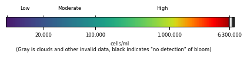

## Caloosahatchee River Estuary

### Discharge

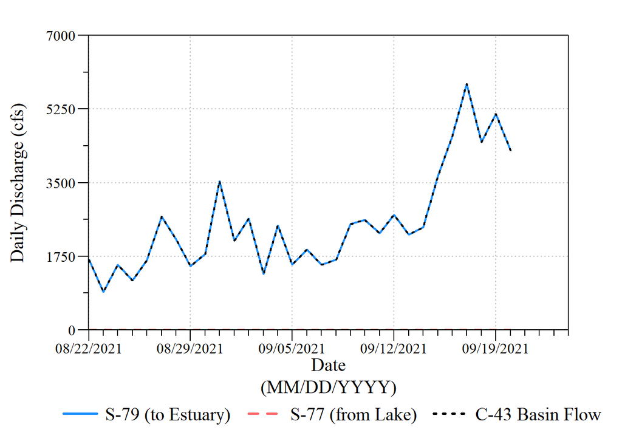

S-77 (from Lake Okeechobee) and S-79 (to Tidal Basin) flow data along the C-43 and Caloosahatchee River. C-43 Basin Flow was calculated as the difference from S-77 and S-79.

Data are provisional and subject to change.

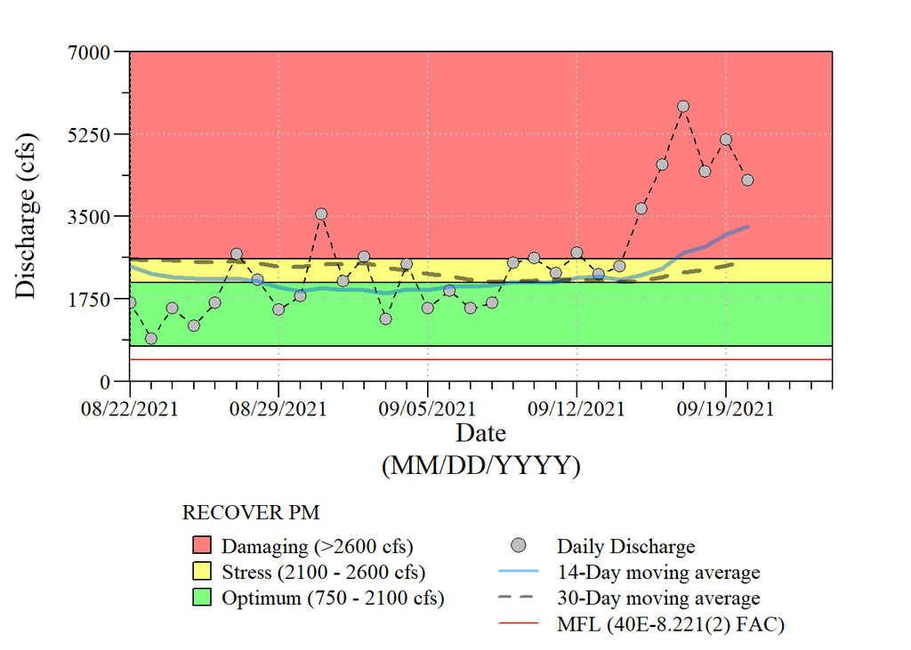

Daily, 14-day moving average and 30-day moving average discharge for S-79 relative to the Northern Estuaries RECOVER performance measure and the established minimium flows and levels (MFLs) for the recent 30-day period.

Data are provisional and subject to change.

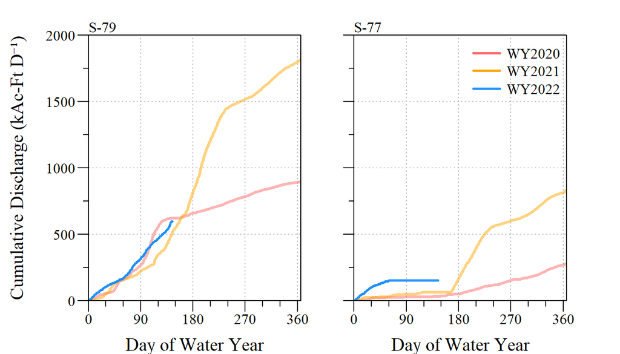

Cumulative discharge for S-79 (to Tidal Basin) and S-77 (from Lake Okeechobee) for the last three Florida Water Years (May - April). Day of water year is analogous to day of year with Day 1 = May 1<sup>st</sup>.

Data are provisional and subject to change.

### Chlorophyll, Phycocyanin & fDOM

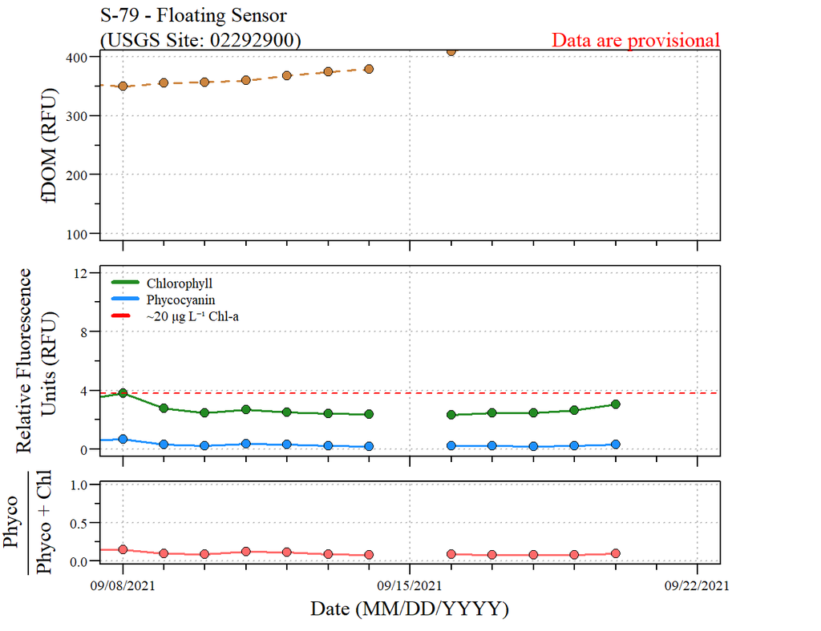

Top: Daily dissolved organic matter (fluorescence DOM). Middle: Daily relative fluorescence Chlorophyll and Phycocyanin observed at the floating sensor bouy at S-79 monitoring by USGS. Bottom: The relative ratio of Phycocyanin (Phyco) relative to Phyco and Chlorophyll (Chl).

Data are provisional and subject to change.

### Salinity Conditions

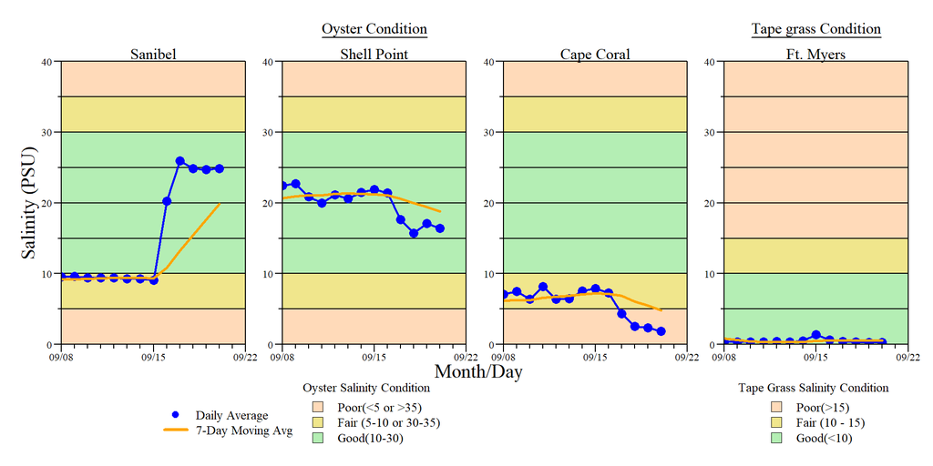

Daily average bottom salinity data for the last 14-days from sampling locations within the tidal Caloosahatchee River Estuary relative to oyster health (Sanibel, Shell Point and Cape Coral) and tape grass (*Vallisneria americana*) health (Ft. Myers only) conditions.

Data are provisional and subject to change.

Site content curated by [SCCF](https://sccf.org) and partners

[SCCF Tech Page](https://sccf-tech.github.io/)

*Contact pjulian@sccf.org with questions*